# Mega-Sena -- Probability, Statistics and Simulations

## Victor Jose Novaes Pires

### 2018-06-25

https://github.com/vicpires/MegaSena/blob/master/MegaSena.ipynb

## Context

The Mega-Sena is the largest lottery in Brazil and is held by the Caixa Econômica Federal bank.

The Mega-Sena has drawings twice a week from a spinning acrylic cage with balls from 01 to 60. Until 2009, they consisted of picking balls from 2 spinning spherical cages. The balls were picked in pairs, in order to form a 2 digit decimal number from 01 to 60. The first cage had balls ranging from 0 to 5 for the first digit, and the other had balls ranging from 0 to 9 to for the second digit. In the event of a 00, it was replaced by a 60. When 6 unique 2 digit numbers were drawn, the drawing was concluded.

Contestants may bet in the range from 6 to 15 numbers, out of 60, and scoring 4, 5 or 6 points will grant prizes. Bet prices escalate depending on how many possible groups of 6 numbers exist within the numbers chosen and they go from R\$ 3.50 for 6 numbers (only 1 possible game) to R\$ 17,517.50 for 15 numbers (5005 unique six numbers games).

[figure not shown]

Sources: https://en.wikipedia.org/wiki/Mega-Sena ; https://pt.wikipedia.org/wiki/Mega-Sena

Official page: http://loterias.caixa.gov.br/wps/portal/loterias/landing/megasena/

## Probability

```python
# A function to print probabilities

def print_probability(p):
    print(f"\nOne chance in {1/p:,.0f} or {(p*100):.2f}% ({(p*100):.2E}%)\n")
```

```python
# The odds of having the first number drawn with a six numbers game

p = 6/60

print_probability(p)
```

```
One chance in 10 or 10.00% (1.00E+01%)
```

```python
# The odds of having the two first numbers drawn with a six numbers game

p = 6/60 * 5/59

print_probability(p)
```

```
One chance in 118 or 0.85% (8.47E-01%)
```

The number of unique six numbers games can be calculated with combinations

$$ \binom{n}{k} = \frac{n!}{k! \cdot (n - k)!} \\ {{60}\choose{6}} = \frac{60!}{6! \cdot (60 - 6)!} = \frac{60!}{6! \cdot 54!} = \frac{60 \cdot 59 \cdot 58 \cdot 57 \cdot 56 \cdot 55 \cdot 54!} {6 \cdot 5 \cdot 4 \cdot 3 \cdot 2 \cdot 1 \cdot 54!} = 50,063,860 $$

```python
# The odds of having all six numbers drawn with a six numbers game

from scipy.special import comb as combinations

c6 = combinations(60, 6)

print_probability(1/c6)
```

```
One chance in 50,063,860 or 0.00% (2.00E-06%)
```

```python
# Other way of calculating the probability

p = 6/60 * 5/59 * 4/58 * 3/57 * 2/56 * 1/55

print_probability(p)
```

```
One chance in 50,063,860 or 0.00% (2.00E-06%)
```

```python
# Those odds are between always getting the same side on 25 coin flips...

p = (1/2)**25

print_probability(p)
```

```
One chance in 33,554,432 or 0.00% (2.98E-06%)
```

```python
# ... and getting always the same side on 26 coin flips

p = (1/2)**26

print_probability(p)
```

```
One chance in 67,108,864 or 0.00% (1.49E-06%)
```

```python
# The odds are a bit better for a seven numbers game...

c = combinations(7, 6)/c6

print_probability(c)
```

```
One chance in 7,151,980 or 0.00% (1.40E-05%)
```

```python
# ... and even more for a ten numbers game

c = combinations(10, 6)/c6

print_probability(c)
```

```
One chance in 238,399 or 0.00% (4.19E-04%)
```

```python
# Similar to getting always the same side on 18 coin tosses

p = (1/2)**18

print_probability(p)
```

```
One chance in 262,144 or 0.00% (3.81E-04%)
```

```python
# What about the R$ 17,517.50 fifteen numbers game

c = combinations(15, 6)/c6

print_probability(c)
```

```
One chance in 10,003 or 0.01% (1.00E-02%)
```

```python
# That is worse than getting always the same side on 13 coin flips

p = (1/2)**13

print_probability(p)
```

```
One chance in 8,192 or 0.01% (1.22E-02%)
```

## Statistics

The dataset with all Mega-Sena results can be downloaded as an HTML spreadsheet from the official government website: http://loterias.caixa.gov.br/wps/portal/loterias/landing/megasena/

```python
# Using Python's regular expressions module to extract the data

import re
```

```python
# The numbers are always two digits, from 01 to 60

number_regex = re.compile(r'\>\d{2}\<')
```

```python
# Dates are in the standard Brazilian format: DD/MM/YYY

date_regex = re.compile(r'\d{2}\/\d{2}\/\d{4}')
```

```python
# A function to convert Brazilian dates (DD/MM/YYY) to ISO 8601 (YYYY-MM-DD)

def br2iso(date):
    return f"{date[-4:]}-{date[3:5]}-{date[0:2]}"
```

```python
# Testing the function above with Christmas

br2iso("25/12/2018")
```

```
'2018-12-25'
```

```python
# Empty lists to store all drawing numbers and dates

all_numbers = list()
all_dates = list()
```

```python
# An empty dictionary to store how many times each number was drawn

times_drawn = {key: 0 for key in range(1,61)}
```

```python
# Extracting the data from the dataset

with open("D_MEGA.HTM", 'rb') as MegaSena_Spreadsheet:
    for row in MegaSena_Spreadsheet:
        date = date_regex.search(f"{row}")
        if (date is not None):
            all_dates.append(br2iso(date.group(0)))
            for _ in range(6): # Six numbers each drawing
                column = MegaSena_Spreadsheet.readline()
                number = number_regex.search(f"{column}")
                if (number is not None):
                    number = int(number.group(0)[1:3])
                    all_numbers.append(number)
                    times_drawn[number] += 1
```

```python
# The number of drawings is equal to the number of dates

total_drawings = len(all_dates)

print(total_drawings)
```

```
2052
```

```python
# all_numbers should be six times the number of drawings

total_numbers = 6*total_drawings

print(f"Expected: {total_numbers}")
print(f"Got: {len(all_numbers)}")
print(f"Match? {total_numbers == len(all_numbers)}!")
```

```
Expected: 12312
Got: 12312
Match? True!
```

```python
# A list with a lists for each drawing

all_drawings = list()
for i in range(total_drawings):
    drawing = all_numbers[(6*i):(6*i+6)]
    all_drawings.append(sorted(drawing))
```

```python
# all_drawings should have the same size as total_drawings

print(f"Expected: {total_drawings}")
print(f"Got: {len(all_drawings)}")
print(f"Match? {total_drawings == len(all_drawings)}!")
```

```
Expected: 2052
Got: 2052
Match? True!
```

```python
# Some games of the all_drawings list

for i in [1, 100, 500, 1000, 1500, 2000, total_drawings]:
    print(f"Drawing {i} was on {all_dates[i-1]} and the numbers were: {all_drawings[i-1]}\n")
```

```
Drawing 1 was on 1996-03-11 and the numbers were: [4, 5, 30, 33, 41, 52]

Drawing 100 was on 1998-02-01 and the numbers were: [14, 29, 30, 46, 48, 51]

Drawing 500 was on 2003-09-27 and the numbers were: [21, 29, 35, 36, 38, 54]

Drawing 1000 was on 2008-08-30 and the numbers were: [29, 38, 39, 49, 53, 58]

Drawing 1500 was on 2013-06-05 and the numbers were: [10, 18, 31, 43, 57, 59]

Drawing 2000 was on 2017-12-31 and the numbers were: [3, 6, 10, 17, 34, 37]

Drawing 2052 was on 2018-06-23 and the numbers were: [50, 51, 56, 57, 58, 59]
```

```python
# The drawing statistics for all numbers

import numpy as np

all_times_np = np.array([v for v in times_drawn.values()])

all_times_mean = int(np.mean(all_times_np))

all_times_sd = np.std(all_times_np)

print(f"Drawn times -- Mean: {all_times_mean} ({np.mean(all_times_np):.2f})")
print(f"Drawn times -- Standard Deviation: {all_times_sd:.2f}")
```

```
Drawn times -- Mean: 205 (205.20)
Drawn times -- Standard Deviation: 14.63
```

```python
# The drawing statistics for each number

for number in times_drawn.keys():
    times = times_drawn[number]
    percent = times / total_numbers * 100
    print(f"Number {number:02d} was drawn {times} times ({percent:.3f}%)", end=" ")

    average = times - all_times_mean
    print(f"[{abs(average):2} times", end=" ")
    if (average >= 0):
        print("above", end=" ")
    else:
        print(f"below", end=" ")
    print("average]")
```

```
Number 01 was drawn 204 times (1.657%) [ 1 times below average]
Number 02 was drawn 209 times (1.698%) [ 4 times above average]
Number 03 was drawn 192 times (1.559%) [13 times below average]
Number 04 was drawn 225 times (1.827%) [20 times above average]
Number 05 was drawn 234 times (1.901%) [29 times above average]
Number 06 was drawn 212 times (1.722%) [ 7 times above average]
Number 07 was drawn 195 times (1.584%) [10 times below average]
Number 08 was drawn 204 times (1.657%) [ 1 times below average]
Number 09 was drawn 184 times (1.494%) [21 times below average]
Number 10 was drawn 232 times (1.884%) [27 times above average]
Number 11 was drawn 198 times (1.608%) [ 7 times below average]
Number 12 was drawn 201 times (1.633%) [ 4 times below average]
Number 13 was drawn 210 times (1.706%) [ 5 times above average]
Number 14 was drawn 193 times (1.568%) [12 times below average]
Number 15 was drawn 186 times (1.511%) [19 times below average]
Number 16 was drawn 212 times (1.722%) [ 7 times above average]
Number 17 was drawn 219 times (1.779%) [14 times above average]
Number 18 was drawn 205 times (1.665%) [ 0 times above average]
Number 19 was drawn 191 times (1.551%) [14 times below average]
Number 20 was drawn 196 times (1.592%) [ 9 times below average]
Number 21 was drawn 179 times (1.454%) [26 times below average]
Number 22 was drawn 181 times (1.470%) [24 times below average]
Number 23 was drawn 228 times (1.852%) [23 times above average]
Number 24 was drawn 221 times (1.795%) [16 times above average]
Number 25 was drawn 187 times (1.519%) [18 times below average]
Number 26 was drawn 166 times (1.348%) [39 times below average]
Number 27 was drawn 211 times (1.714%) [ 6 times above average]
Number 28 was drawn 219 times (1.779%) [14 times above average]
Number 29 was drawn 210 times (1.706%) [ 5 times above average]
Number 30 was drawn 215 times (1.746%) [10 times above average]
Number 31 was drawn 198 times (1.608%) [ 7 times below average]
Number 32 was drawn 217 times (1.763%) [12 times above average]
Number 33 was drawn 224 times (1.819%) [19 times above average]
Number 34 was drawn 210 times (1.706%) [ 5 times above average]
Number 35 was drawn 204 times (1.657%) [ 1 times below average]
Number 36 was drawn 210 times (1.706%) [ 5 times above average]
Number 37 was drawn 211 times (1.714%) [ 6 times above average]
Number 38 was drawn 204 times (1.657%) [ 1 times below average]
Number 39 was drawn 192 times (1.559%) [13 times below average]
Number 40 was drawn 195 times (1.584%) [10 times below average]
Number 41 was drawn 211 times (1.714%) [ 6 times above average]
Number 42 was drawn 218 times (1.771%) [13 times above average]
Number 43 was drawn 213 times (1.730%) [ 8 times above average]
Number 44 was drawn 209 times (1.698%) [ 4 times above average]
Number 45 was drawn 203 times (1.649%) [ 2 times below average]
Number 46 was drawn 195 times (1.584%) [10 times below average]
Number 47 was drawn 201 times (1.633%) [ 4 times below average]
Number 48 was drawn 190 times (1.543%) [15 times below average]
Number 49 was drawn 201 times (1.633%) [ 4 times below average]
Number 50 was drawn 213 times (1.730%) [ 8 times above average]
Number 51 was drawn 223 times (1.811%) [18 times above average]
Number 52 was drawn 219 times (1.779%) [14 times above average]
Number 53 was drawn 234 times (1.901%) [29 times above average]
Number 54 was drawn 225 times (1.827%) [20 times above average]
Number 55 was drawn 175 times (1.421%) [30 times below average]
Number 56 was drawn 212 times (1.722%) [ 7 times above average]
Number 57 was drawn 190 times (1.543%) [15 times below average]
Number 58 was drawn 201 times (1.633%) [ 4 times below average]
Number 59 was drawn 203 times (1.649%) [ 2 times below average]
Number 60 was drawn 192 times (1.559%) [13 times below average]
```

```python
# A list of number's popularity, sorted by the times it was drawn

popular = [p[0] for p in sorted(times_drawn.items(), key=lambda d: d[1], reverse=True)]

print(f"Most popular number: {popular[0]:02d}; Drawn: {times_drawn[popular[0]]} times.")
print(f"\nLeast popular number: {popular[-1]:02d}; Drawn: {times_drawn[popular[-1]]} times.")
```

```
Most popular number: 05; Drawn: 234 times.

Least popular number: 26; Drawn: 166 times.
```

```python
print("The 15 most popular numbers are:")
for i in range(15):
    number = popular[i]
    times = times_drawn[number]
    average = times - all_times_mean
    print(f"{(i+1):2d}: Number {number:02d} was drawn {times} times; {average} drawings above average.")
```

```
The 15 most popular numbers are:
 1: Number 05 was drawn 234 times; 29 drawings above average.
 2: Number 53 was drawn 234 times; 29 drawings above average.
 3: Number 10 was drawn 232 times; 27 drawings above average.
 4: Number 23 was drawn 228 times; 23 drawings above average.
 5: Number 04 was drawn 225 times; 20 drawings above average.
 6: Number 54 was drawn 225 times; 20 drawings above average.
 7: Number 33 was drawn 224 times; 19 drawings above average.
 8: Number 51 was drawn 223 times; 18 drawings above average.
 9: Number 24 was drawn 221 times; 16 drawings above average.
10: Number 17 was drawn 219 times; 14 drawings above average.
11: Number 28 was drawn 219 times; 14 drawings above average.
12: Number 52 was drawn 219 times; 14 drawings above average.
13: Number 42 was drawn 218 times; 13 drawings above average.
14: Number 32 was drawn 217 times; 12 drawings above average.
15: Number 30 was drawn 215 times; 10 drawings above average.
```

```python
print("The 15 least popular numbers are:")
for i in range(15):
    number = popular[(59-i)]
    times = times_drawn[number]
    average = all_times_mean - times
    print(f"{(60-i)}: Number {number:02d} was drawn {times} times; {average} drawings below average.")
```

```
The 15 least popular numbers are:
60: Number 26 was drawn 166 times; 39 drawings below average.
59: Number 55 was drawn 175 times; 30 drawings below average.
58: Number 21 was drawn 179 times; 26 drawings below average.
57: Number 22 was drawn 181 times; 24 drawings below average.
56: Number 09 was drawn 184 times; 21 drawings below average.
55: Number 15 was drawn 186 times; 19 drawings below average.
54: Number 25 was drawn 187 times; 18 drawings below average.
53: Number 57 was drawn 190 times; 15 drawings below average.
52: Number 48 was drawn 190 times; 15 drawings below average.
51: Number 19 was drawn 191 times; 14 drawings below average.
50: Number 60 was drawn 192 times; 13 drawings below average.
49: Number 39 was drawn 192 times; 13 drawings below average.
48: Number 03 was drawn 192 times; 13 drawings below average.
47: Number 14 was drawn 193 times; 12 drawings below average.
46: Number 46 was drawn 195 times; 10 drawings below average.
```

```python
# Plot setup

import matplotlib.pyplot as plt

from matplotlib import style

%matplotlib inline

# MATLAB colors
blue   = [0.0000, 0.4470, 0.7410]
green  = [0.4660, 0.6740, 0.1880]
yellow = [0.9290, 0.6940, 0.1250]
orange = [0.8500, 0.3250, 0.0980]
black  = [0.2500, 0.2500, 0.2500]
```

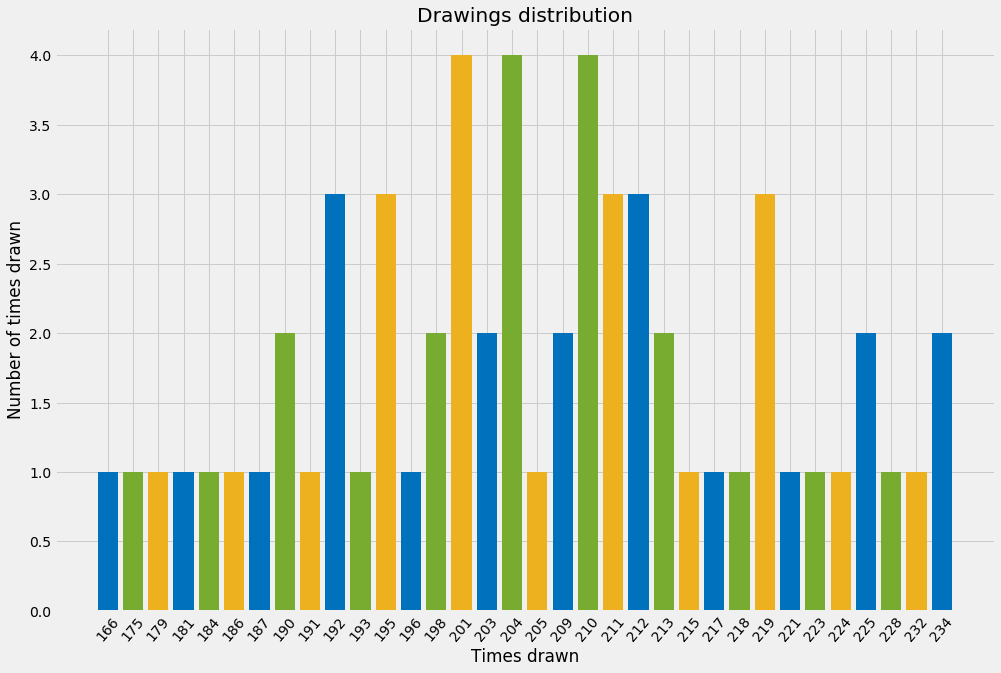

```python
# Bar plot for the number of times numbers were drawn

drawings = {key : 0 for key in sorted(times_drawn.values())}
for value in times_drawn.values():
    drawings[value] += 1
x = [k for k in range(len(drawings.keys()))]
y = [v for v in drawings.values()]

style.use('fivethirtyeight')
plt.figure(figsize=(15, 10))
plt.bar(x, y, color=[blue, green, yellow])
plt.xticks(x, [f"{k}" for k in drawings.keys()], rotation=50)
plt.title("Drawings distribution")
plt.xlabel("Times drawn")
plt.ylabel("Number of times drawn")
plt.show()
```

```python
# A function to plot drawings statistics

def plot_bars(x, y, title):
    mean = np.mean(y)
    sd = np.std(y)
    print(f"Mean: {mean:.2f} <> SD: {sd:.2f}")

    style.use('fivethirtyeight')
    plt.figure(figsize=(15, 10))

    plt.bar(x, y, color=[blue, green, yellow])

    plt.xticks(np.append(np.array(1), np.arange(5,61,5)))

    xs = [(min(x) - 1), (1 + max(x))]
    plt.plot(xs, ([mean + sd] * 2), linewidth=1, color=black, label="Mean + SD")
    plt.plot(xs, ([mean] * 2), linewidth=2, color=orange, label="Mean")
    plt.plot(xs, ([mean - sd] * 2), linewidth=1, color=black, label="Mean - SD")

    plt.title(title)
    plt.xlabel("Numbers")
    plt.ylabel("Drawings")
    plt.legend(loc=4)

    plt.show()
```

```
Mean: 205.20 <> SD: 14.63
```

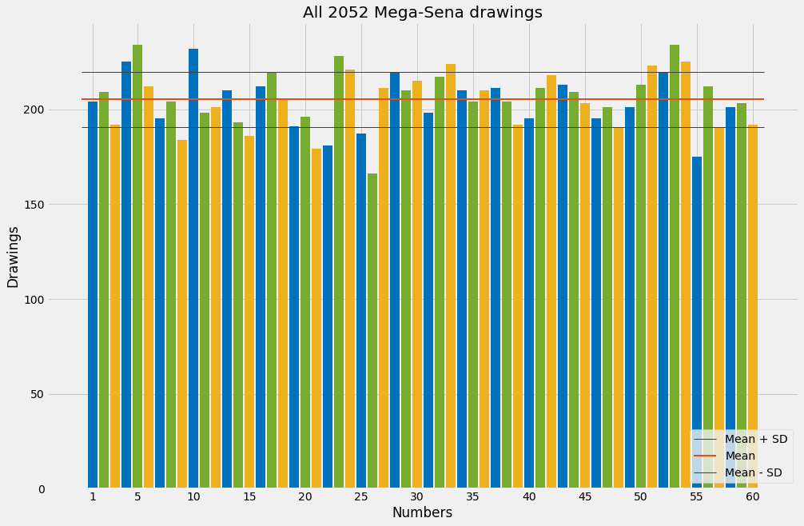

```python
# A plot of all Mega-Sena drawings

title = f"All {total_drawings} Mega-Sena drawings"
x = [k for k in times_drawn.keys()]
y = [v for v in times_drawn.values()]
plot_bars(x, y, title)
```

```python
# A function to plot a range of Mega-Sena drawings

def range_plot(x):
    lower = (x[0] - 1)
    upper = (x[1] - 1)
    if (lower < upper):
        start_date = all_dates[lower]
        end_date = all_dates[upper]
        num_drawings = upper - lower + 1
        title = f"Statistics of {num_drawings} drawings: {start_date} - {end_date}"

        numbers = all_numbers[(lower*6):(upper*6+6)]
        drawings = {key: 0 for key in range(1,61)}
        for number in numbers:
            drawings[number] += 1

        x = [k for k in drawings.keys()]
        y = [v for v in drawings.values()]

        plot_bars(x, y, title)
```

```
Mean: 16.20 <> SD: 4.38
```

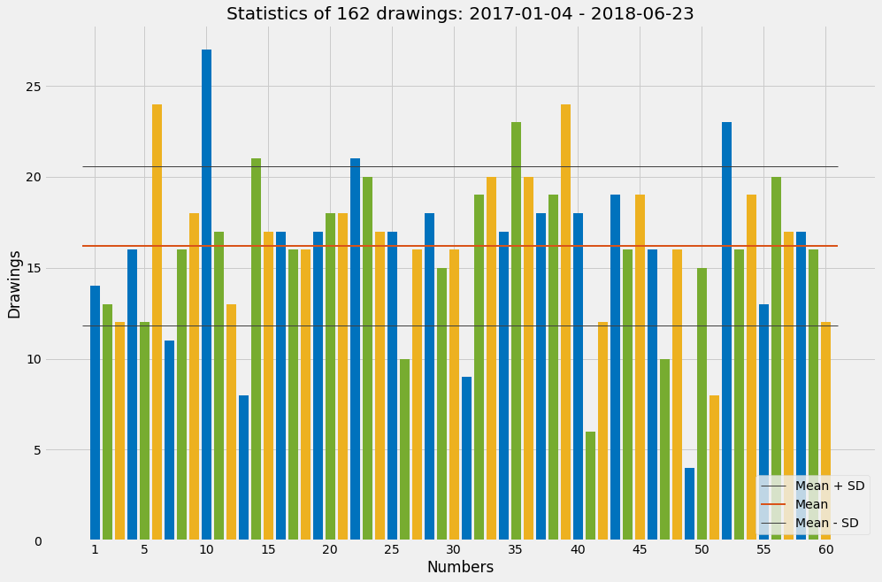

```python
# A plot of the drawings from 2017 to 2018

range_plot([1891, total_drawings])
```

```python
# Interactive plot of the Mega-Sena drawings (default: 2017 - 2018)

from ipywidgets import widgets, interact, Layout

s = widgets.IntRangeSlider(value=[1891, total_drawings], min=1, max=total_drawings, layout=Layout(width='95%'))
interact(range_plot, x=s);
```

```python
# A function to print statistics for each number of the drawing

def print_drawing_stats(last_drawing, this_drawing):
    for number in this_drawing:
        times = times_drawn[number]
        print(f"Number {number:02d}; drawn {times} times;", end=" ")

        average = times - all_times_mean
        print(f"{abs(average):2}", end=" ")
        if (average >= 0):
            print("above", end=" ")
        else:
            print(f"below", end=" ")
        print("average;", end=" ")

        print(f"In last drawing: ", end="")
        if (number in last_drawing):
            print("Yes!", end=" ")
        else:
            print("No. ", end=" ")

        popularity = popular.index(number) + 1
        print(f"Popularity: {popularity:02d}", end="")
        if (popularity <= 15):
            print(" (top 15)")
        elif(popularity > 45):
            print(" (bottom 15)")
        else:
            print()
```

```python
# Statistics for the last five drawings

for i in range(5):
    last_drawing = all_drawings[(i-6)]
    this_drawing = all_drawings[(i-5)]
    print(f"\nDrawing {total_drawings-4+i} - {all_dates[(total_drawings-5+i)]}")
    print_drawing_stats(last_drawing, this_drawing)
```

```
Drawing 2048 - 2018-06-09
Number 10; drawn 232 times; 27 above average; In last drawing: No.  Popularity: 03 (top 15)
Number 19; drawn 191 times; 14 below average; In last drawing: Yes! Popularity: 51 (bottom 15)
Number 26; drawn 166 times; 39 below average; In last drawing: No.  Popularity: 60 (bottom 15)
Number 35; drawn 204 times;  1 below average; In last drawing: No.  Popularity: 33
Number 38; drawn 204 times;  1 below average; In last drawing: No.  Popularity: 34
Number 39; drawn 192 times; 13 below average; In last drawing: No.  Popularity: 49 (bottom 15)

Drawing 2049 - 2018-06-13
Number 10; drawn 232 times; 27 above average; In last drawing: Yes! Popularity: 03 (top 15)
Number 19; drawn 191 times; 14 below average; In last drawing: Yes! Popularity: 51 (bottom 15)
Number 27; drawn 211 times;  6 above average; In last drawing: No.  Popularity: 21
Number 31; drawn 198 times;  7 below average; In last drawing: No.  Popularity: 42
Number 51; drawn 223 times; 18 above average; In last drawing: No.  Popularity: 08 (top 15)
Number 53; drawn 234 times; 29 above average; In last drawing: No.  Popularity: 02 (top 15)

Drawing 2050 - 2018-06-16
Number 08; drawn 204 times;  1 below average; In last drawing: No.  Popularity: 32
Number 31; drawn 198 times;  7 below average; In last drawing: Yes! Popularity: 42
Number 32; drawn 217 times; 12 above average; In last drawing: No.  Popularity: 14 (top 15)
Number 33; drawn 224 times; 19 above average; In last drawing: No.  Popularity: 07 (top 15)
Number 38; drawn 204 times;  1 below average; In last drawing: No.  Popularity: 34
Number 50; drawn 213 times;  8 above average; In last drawing: No.  Popularity: 17

Drawing 2051 - 2018-06-20
Number 01; drawn 204 times;  1 below average; In last drawing: No.  Popularity: 31
Number 05; drawn 234 times; 29 above average; In last drawing: No.  Popularity: 01 (top 15)
Number 06; drawn 212 times;  7 above average; In last drawing: No.  Popularity: 18
Number 37; drawn 211 times;  6 above average; In last drawing: No.  Popularity: 22
Number 44; drawn 209 times;  4 above average; In last drawing: No.  Popularity: 29
Number 53; drawn 234 times; 29 above average; In last drawing: No.  Popularity: 02 (top 15)

Drawing 2052 - 2018-06-23
Number 50; drawn 213 times;  8 above average; In last drawing: No.  Popularity: 17
Number 51; drawn 223 times; 18 above average; In last drawing: No.  Popularity: 08 (top 15)
Number 56; drawn 212 times;  7 above average; In last drawing: No.  Popularity: 20
Number 57; drawn 190 times; 15 below average; In last drawing: No.  Popularity: 53 (bottom 15)
Number 58; drawn 201 times;  4 below average; In last drawing: No.  Popularity: 40
Number 59; drawn 203 times;  2 below average; In last drawing: No.  Popularity: 36
```

```
The six numbers of the last drawing, #2052 on 2018-06-23, are: [50, 51, 56, 57, 58, 59].

Mean: 205.00 <> SD: 14.63
```

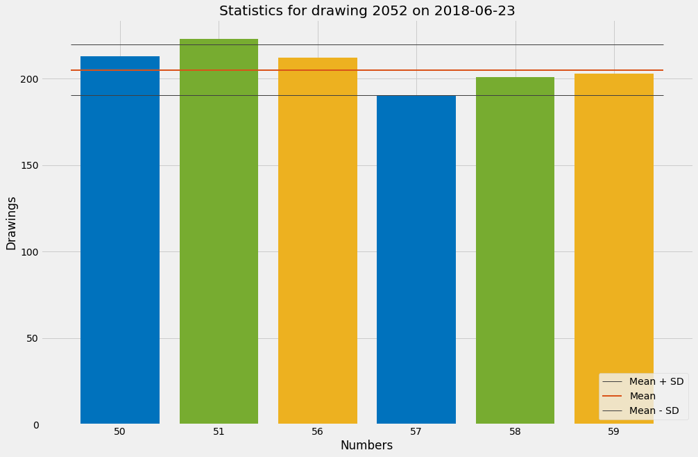

```python
# Plot the statistics for the last drawing

last_date = all_dates[-1]
last_drawing = all_drawings[-1]

print(f"\nThe six numbers of the last drawing, #{total_drawings} on {last_date}, are: {last_drawing}.\n")

print(f"Mean: {all_times_mean:.2f} <> SD: {all_times_sd:.2f}")

style.use('fivethirtyeight')

plt.figure(figsize=(15, 10))

xs = np.arange(6)
plt.bar(xs, [times_drawn[number] for number in last_drawing], color=[blue, green, yellow])
plt.xticks(xs, [f"{number}" for number in last_drawing])

xs = [(min(xs) - 0.5), (0.5 + max(xs))]
plt.plot(xs, ([all_times_mean + all_times_sd] * 2), linewidth=1, color=black, label="Mean + SD")
plt.plot(xs, ([all_times_mean] * 2), linewidth=2, color=orange, label="Mean")
plt.plot(xs, ([all_times_mean - all_times_sd] * 2), linewidth=1, color=black, label="Mean - SD")
plt.legend(loc=4)

plt.title(f"Statistics for drawing {total_drawings} on {last_date}")
plt.xlabel("Numbers")
plt.ylabel("Drawings")

plt.show()
```

```python
# Was there ever a repeated drawing?

drawings_st = set(tuple(d) for d in all_drawings)

print(f"Total drawings: {len(all_drawings)}")
print(f"Unique drawings: {len(drawings_st)}")
print(f"Repeated drawings: {len(all_drawings) != len(drawings_st)}")
```

```
Total drawings: 2052
Unique drawings: 2052
Repeated drawings: False
```

```python
# How many unique games are possible on the birthday range (01 to 31)

cb = combinations(31, 6)

print(f"There are {cb:,.0f} unique games in the range 01 to 31.")
print(f"\nThat is {cb/c6*100:.2f}% of all {c6:,.0f} unique six number games.")
```

```
There are 736,281 unique games in the range 01 to 31.

That is 1.47% of all 50,063,860 unique six number games.
```

```python
# How many drawings were on the birthdays range? (01 to 31)

birthday_drawings = list()
for i in range(total_drawings):
    if (max(all_drawings[i]) <= 31):
        birthday_drawings.append((i, all_drawings[i]))

print(f"""There were {len(birthday_drawings)} "birthday" games out of all {total_drawings} drawings.""")
print(f"\nThat is {(len(birthday_drawings)/total_drawings*100):.2f}% of the winning drawings.")
```

```
There were 21 "birthday" games out of all 2052 drawings.

That is 1.02% of the winning drawings.
```

```python
print("""All "birthday" drawings:\n""")
for i, drawing in enumerate(birthday_drawings):
    print(f"{(i+1):02d}: {all_dates[drawing[0]]} - {drawing[1]}")
```

```
All "birthday" drawings:

01: 2002-08-07 - [5, 12, 16, 18, 22, 24]
02: 2003-07-09 - [3, 8, 21, 25, 30, 31]
03: 2006-10-21 - [5, 11, 15, 23, 25, 30]
04: 2008-08-02 - [1, 4, 6, 8, 25, 28]
05: 2008-08-16 - [7, 15, 20, 21, 23, 29]
06: 2008-09-10 - [5, 10, 16, 23, 26, 27]
07: 2009-11-18 - [5, 8, 14, 24, 29, 30]
08: 2010-02-17 - [4, 12, 14, 21, 26, 28]
09: 2010-06-02 - [4, 9, 23, 27, 28, 30]
10: 2010-11-17 - [8, 11, 12, 15, 18, 22]
11: 2011-08-20 - [5, 20, 22, 28, 29, 30]
12: 2011-11-05 - [1, 6, 8, 10, 25, 27]
13: 2012-05-19 - [4, 19, 27, 28, 29, 31]
14: 2013-11-13 - [2, 9, 10, 18, 21, 28]
15: 2015-06-13 - [3, 10, 16, 23, 27, 29]
16: 2016-02-04 - [1, 5, 13, 25, 26, 29]
17: 2016-10-20 - [1, 5, 23, 25, 28, 31]
18: 2017-01-21 - [3, 6, 14, 15, 21, 25]
19: 2017-02-11 - [2, 7, 9, 18, 21, 25]
20: 2017-05-06 - [5, 11, 13, 19, 30, 31]
21: 2017-05-31 - [1, 3, 10, 17, 23, 24]
```

```python
# What about the lazy first six digits game?

game = [x for x in range(1,7)]

print(f"Is game {game} in the drawings? {game in all_drawings}!")
```

```
Is game [1, 2, 3, 4, 5, 6] in the drawings? False!
```

## Simulation

```python
# A function to print drawing simulation statistics

def print_simulation_stats(stats):
    percent = stats / simulation_iterations * 100
    print(f"In {simulation_iterations:,} drawings numbers were picked twice on the same drawing", end=" ")
    print(f"{stats:,} times. ({percent:.2f}%)")
    print(f"\nOne redraw every {simulation_iterations*6/stats:.2f} balls on average.")
```

```python
# Until 2009 it was two balls, one for tens and one for units

def draw():
    twice = 0 # Store how many times identical numbers were drawn
    drawing = list()
    while (len(drawing) < 6):
        tens = np.random.choice(np.arange(0, 6, dtype=np.uint8))
        units = np.random.choice(np.arange(0, 10, dtype=np.uint8))
        number = (tens * 10) + units
        if (number == 0): # A double zero becomes 60
            number = 60

        if (number not in drawing):
            drawing.append(number)
        else: # Identical number, draw again
            twice += 1

    drawing = sorted(drawing)

    return np.array(drawing, dtype=np.uint8), twice
```

```python
# Simulating an old drawing

drawing = draw()[0]

print(f"Drawing: {drawing}")
```

```
Drawing: [20 32 33 37 44 48]
```

```python
# How often identical numbers would be drawn

simulation_iterations = int(1e6) # One million

twice = 0
for _ in range(simulation_iterations):
    twice += draw()[1]

print_simulation_stats(twice)
```

```
In 1,000,000 drawings numbers were picked twice on the same drawing 266,484 times. (26.65%)

One redraw every 22.52 balls on average.
```

```python
# What about balls from 01 to 60 with replacement

def draw():
    twice = 0
    drawing = list()
    while (len(drawing) < 6):
        number = np.random.choice(np.arange(1, 61, dtype=np.uint8))
        if (number not in drawing):
            drawing.append(number)
        else:
            twice += 1
    drawing = sorted(drawing)

    return np.array(drawing, dtype=np.uint8), twice
```

```python
# Simulating again to see how often identical numbers would be drawn

twice = 0
for _ in range(simulation_iterations):
    twice += draw()[1]

print_simulation_stats(twice)
```

```
In 1,000,000 drawings numbers were picked twice on the same drawing 265,700 times. (26.57%)

One redraw every 22.58 balls on average.
```

```python
# With no replacement numbers never repeat in a drawing

def draw(size):
    game = np.random.choice(np.arange(1, 61, dtype=np.uint8), size, replace=False)
    return np.sort(game)
```

```python
# Simulating yet another drawing

drawing = draw(6)

print(f"Drawing: {drawing}")
```

```
Drawing: [13 15 22 28 38 58]
```

```python
# It is also possible to use the function to make six and a fifteen numbers game

game6 = draw(6)
game15 = draw(15)

print(f"Six numbers game: {game6}")
print(f"\nFifteen numbers game: {game15}")
```

```
Six numbers game: [ 3 22 26 32 40 53]

Fifteen numbers game: [ 4 15 19 22 29 36 39 44 47 48 50 55 57 58 59]
```

```python
# A function to calculate how many points a game did

def get_points(drawing, game):
    points = 0
    for number in game:
        if number in drawing:
            points += 1
    return points
```

```python
# Calculating the points for the two games above

print(f"\nDrawing: {drawing}")

for game in [game6, game15]:
    print(f"\nGame {game} scored {get_points(drawing, game)} point(s).")
```

```
Drawing: [13 15 22 28 38 58]

Game [ 3 22 26 32 40 53] scored 1 point(s).

Game [ 4 15 19 22 29 36 39 44 47 48 50 55 57 58 59] scored 3 point(s).
```

```python
# A function to simulate many games and get some statistics

def simulate_games(drawing, game_size, iterations):
    points = {p: 0 for p in range(7)}

    for _ in range(iterations):
        game = draw(game_size)
        p = get_points(drawing, game)
        points[p] += 1

    return points
```

```python
# A function to pretty print the simulated statistics of many games

def print_sim_stats(stats):
    total = sum(stats.values())
    for points, games in enumerate(stats.values()):
        print(f"{points} points: {games:,} games ({(games/total*100):.3f}%)")
```

```python
# Function to plot simulation statistics

def plot_sim_stats(stats, title):
    style.use('fivethirtyeight')
    plt.figure(figsize=(15, 10))

    plt.bar([k for k in stats.keys()], [v for v in stats.values()], color=[blue, green, yellow])

    plt.title(title)
    plt.xlabel("Points")
    plt.ylabel("Games")

    plt.show()
```

```
0 points: 515,894 games (51.589%)
1 points: 379,139 games (37.914%)
2 points: 94,734 games (9.473%)
3 points: 9,848 games (0.985%)
4 points: 379 games (0.038%)
5 points: 6 games (0.001%)
6 points: 0 games (0.000%)
```

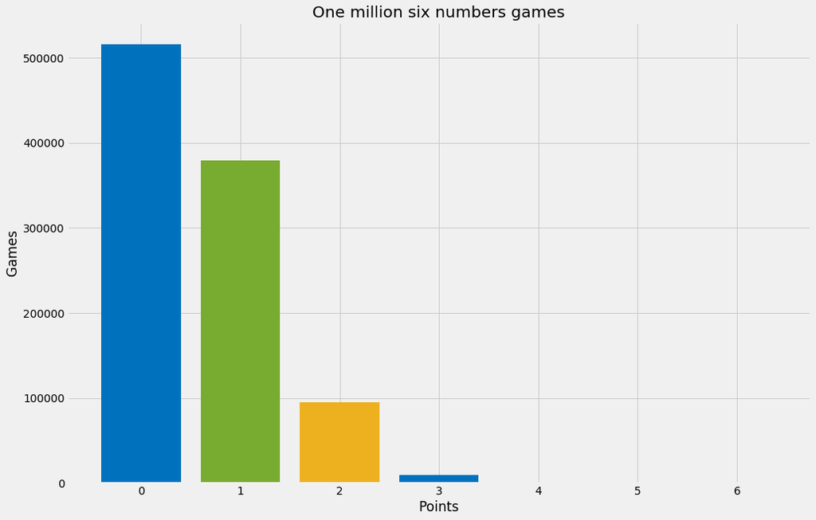

```python
# Simulation of one million six numbers games

sim6 = simulate_games(drawing, 6, simulation_iterations)

print_sim_stats(sim6)

plot_sim_stats(sim6, "One million six numbers games")
```

```
0 points: 162,179 games (16.218%)
1 points: 366,932 games (36.693%)
2 points: 312,285 games (31.228%)
3 points: 128,581 games (12.858%)
4 points: 27,273 games (2.727%)
5 points: 2,633 games (0.263%)
6 points: 117 games (0.012%)
```

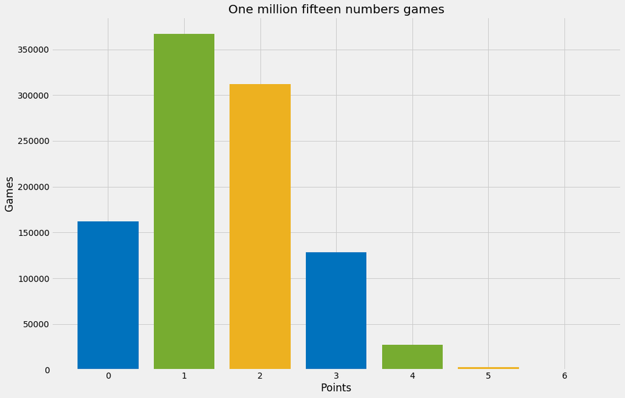

```python
# Simulation of one million fifteen numbers games

sim15 = simulate_games(drawing, 15, simulation_iterations)

print_sim_stats(sim15)

plot_sim_stats(sim15, "One million fifteen numbers games")
```

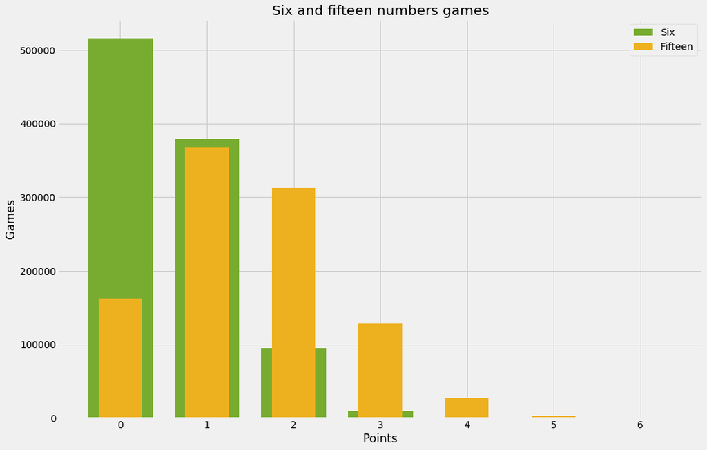

```python
# Both simulations together

style.use('fivethirtyeight')
plt.figure(figsize=(15, 10))

plt.bar([k for k in sim6.keys()], [v for v in sim6.values()], color=green, label="Six", width=0.75)
plt.bar([k for k in sim15.keys()], [v for v in sim15.values()], color=yellow, label="Fifteen", width=0.50)

plt.title("Six and fifteen numbers games")
plt.xlabel("Points")
plt.ylabel("Games")
plt.legend()

plt.show()
```

## Conclusions

Lottery statistics are interesting, fun to analyze and simulate!

Future drawings **cannot** be predicted since they have no correlation with previous drawings.

The odds are against those who bet only on birthdays, the first 31 numbers, and forget about the other half.

After all this I would say that Mega-Sena is a good investment option since with just only one dollar you have your, *teeny tiny*, chance of winning millions.

Victor Jose Novaes Pires

2018-06-25

https://github.com/vicpires/MegaSena/blob/master/MegaSena.ipynb